# DIID

KonstantinPopadin

8/19/2024

## 1 Read data, derive DeficitOfFragility

```r
# Set the file path
file_path <- "2_Derived/Total_DIID_count.csv"
data <- read.table(file_path, sep = ';', header = TRUE)

# Display the first few rows of the data
names(data)
```

```
##  [1] "Spece"                "DirectRepeatLength"   "InvertedRepeatLength"
##  [4] "LengthOfInterval1"    "LengthOfInterval2"    "LengthOfInterval3"
##  [7] "DI..I.Dcount"         "D.I..IDcount"         "DG4I..I.Dcount"
## [10] "D.I..IG4Dcount"       "DIIDsupremacy"        "GqSupremacy"
## [13] "DIIDFragilityScore"   "DG4IIDFragilityScore" "d1_0k"
## [16] "d1_1k"                "d1_2k"                "d1_3k"
## [19] "d1_4k"                "d1_5k"                "d1_6k"
## [22] "d1_7k"                "d1_8k"                "d1_9k"
## [25] "d1_10k"               "d1_11k"               "d1_12k"
## [28] "d1_13k"               "d1_14k"               "d1_15k"
## [31] "d1_16k"               "d1_17k"               "d2_0k"
## [34] "d2_1k"                "d2_2k"                "d2_3k"
## [37] "d2_4k"                "d2_5k"                "d2_6k"
## [40] "d2_7k"                "d2_8k"                "d2_9k"
## [43] "d2_10k"               "d2_11k"               "d2_12k"
## [46] "d2_13k"               "d2_14k"               "d2_15k"
## [49] "d2_16k"               "d2_17k"               "i1_0k"
## [52] "i1_1k"                "i1_2k"                "i1_3k"
## [55] "i1_4k"                "i1_5k"                "i1_6k"
## [58] "i1_7k"                "i1_8k"                "i1_9k"
## [61] "i1_10k"               "i1_11k"               "i1_12k"
## [64] "i1_13k"               "i1_14k"               "i1_15k"
## [67] "i1_16k"               "i1_17k"               "i2_0k"
## [70] "i2_1k"                "i2_2k"                "i2_3k"
## [73] "i2_4k"                "i2_5k"                "i2_6k"
## [76] "i2_7k"                "i2_8k"                "i2_9k"
## [79] "i2_10k"               "i2_11k"               "i2_12k"
## [82] "i2_13k"               "i2_14k"               "i2_15k"
## [85] "i2_16k"               "i2_17k"
```

```r
summary(data$DIIDFragilityScore)
```

```
##    Min. 1st Qu.  Median    Mean 3rd Qu.    Max.
##  0.0000  0.0000  0.0000  0.3882  0.5385 10.0000
```

```r
data$DIID.DeficitOfFragility = data$D.I..IDcount - data$DI..I.Dcount # ALTER - FRAGILE: the higher the score the higher the deficit of fragile elements ( due to potential selection)
summary(data$DIID.DeficitOfFragility)
```

```
##    Min. 1st Qu.  Median    Mean 3rd Qu.    Max.
## -111.00    0.00    0.00   -1.26    0.00   30.00
```

## 2 DIIDFragilityScore (==number of fragile / number of alternative structures)

### we expect that FragilityScore should decrease (due to selection) in case of:

### (i) long repeats (so we expect negative correlations between FragilityScore and length);

### (ii) short intervals 1 and 3 (so we expect positive correlations between FragilityScore and interval length)

### in a set of univariate and multivariate analyses below we observe exactly this.

```r
summary(data$DirectRepeatLength)
```

```
##    Min. 1st Qu.  Median    Mean 3rd Qu.    Max.
##    10.0    12.0    14.5    14.5    17.0    19.0
```

```r
summary(data$InvertedRepeatLength)
```

```
##    Min. 1st Qu.  Median    Mean 3rd Qu.    Max.
##    10.0    12.0    14.5    14.5    17.0    19.0
```

```r
### UNIVARIATE WITH DIIDFragilityScore

cor.test(data$DIIDFragilityScore,data$DirectRepeatLength, method = 'spearman')
```

```
##
##  Spearman's rank correlation rho
##
## data:  data$DIIDFragilityScore and data$DirectRepeatLength
## S = 1.7327e+11, p-value < 2.2e-16
## alternative hypothesis: true rho is not equal to 0
## sample estimates:
##        rho
## -0.4261254
```

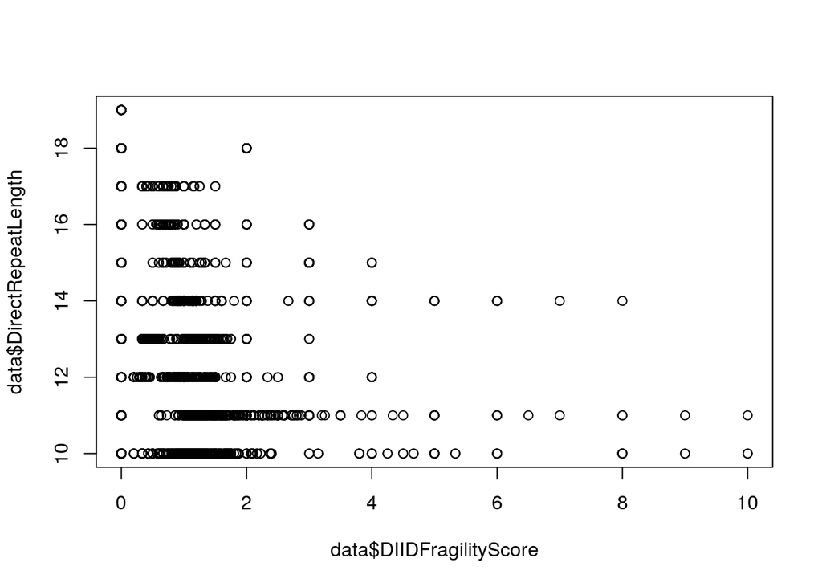

```r
plot(data$DIIDFragilityScore,data$DirectRepeatLength)
```

```r
cor.test(data$DIIDFragilityScore,data$InvertedRepeatLength, method = 'spearman')
```

```
##
##  Spearman's rank correlation rho
##
## data:  data$DIIDFragilityScore and data$InvertedRepeatLength
## S = 1.9351e+11, p-value < 2.2e-16
## alternative hypothesis: true rho is not equal to 0
## sample estimates:
##        rho
## -0.5926468
```

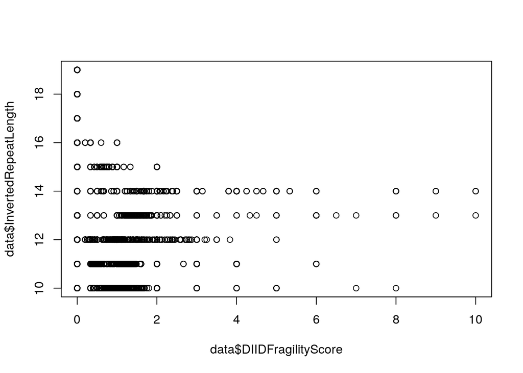

```r
plot(data$DIIDFragilityScore,data$InvertedRepeatLength)
```

```r
cor.test(data$DIIDFragilityScore,data$LengthOfInterval1, method = 'spearman')
```

```
##
##  Spearman's rank correlation rho
##
## data:  data$DIIDFragilityScore and data$LengthOfInterval1
## S = 1.0954e+11, p-value < 2.2e-16
## alternative hypothesis: true rho is not equal to 0
## sample estimates:
##        rho
## 0.09843036
```

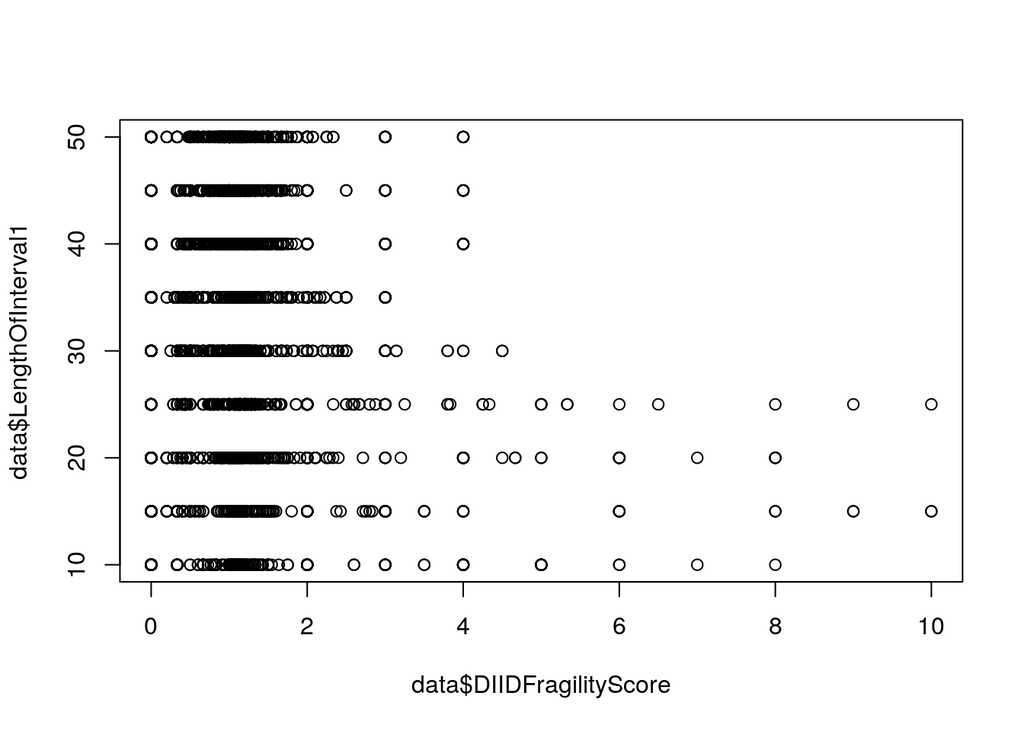

```r
plot(data$DIIDFragilityScore,data$LengthOfInterval1)
```

```r
cor.test(data$DIIDFragilityScore,data$LengthOfInterval2, method = 'spearman')
```

```
##
##  Spearman's rank correlation rho
##
## data:  data$DIIDFragilityScore and data$LengthOfInterval2
## S = 1.219e+11, p-value = 0.7545
## alternative hypothesis: true rho is not equal to 0
## sample estimates:
##          rho
## -0.003296352
```

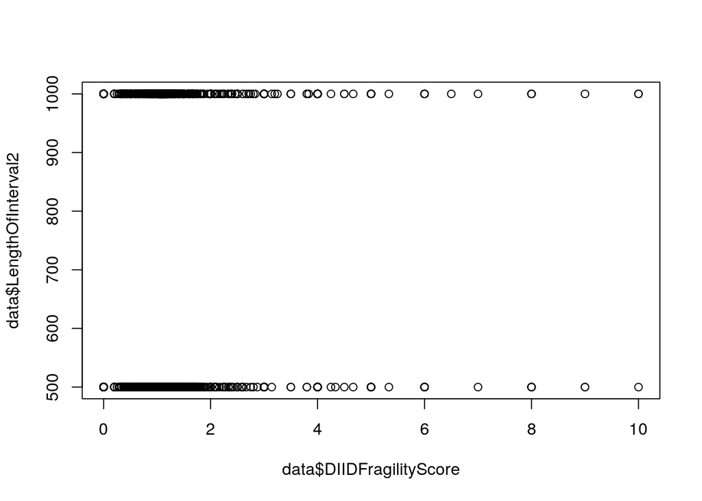

```r
plot(data$DIIDFragilityScore,data$LengthOfInterval2)
```

```r
cor.test(data$DIIDFragilityScore,data$LengthOfInterval3, method = 'spearman')
```

```
##
##  Spearman's rank correlation rho
##
## data:  data$DIIDFragilityScore and data$LengthOfInterval3
## S = 1.1891e+11, p-value = 0.04309
## alternative hypothesis: true rho is not equal to 0
## sample estimates:
##        rho
## 0.02132324
```

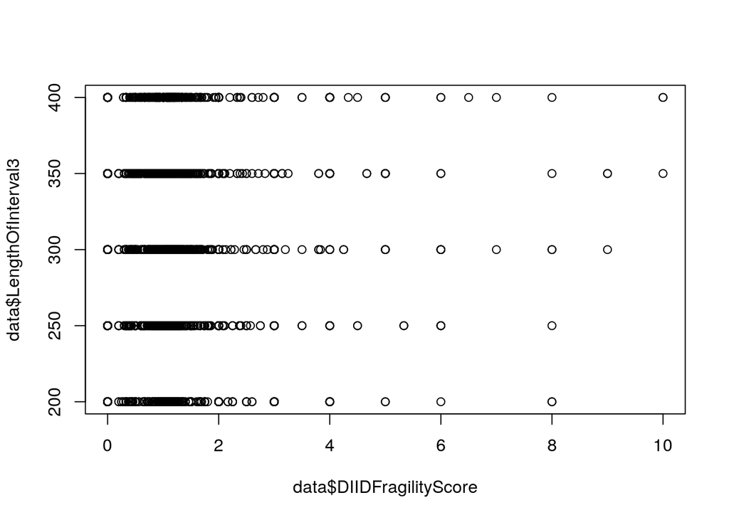

```r
plot(data$DIIDFragilityScore,data$LengthOfInterval3)
```

```r
### MULTIVARIATE

summary(lm(data$DIIDFragilityScore ~ scale(data$DirectRepeatLength) + scale(data$InvertedRepeatLength) + scale(data$LengthOfInterval1) + scale(data$LengthOfInterval2) + scale(data$LengthOfInterval3)))
```

```
##
## Call:
## lm(formula = data$DIIDFragilityScore ~ scale(data$DirectRepeatLength) +
##     scale(data$InvertedRepeatLength) + scale(data$LengthOfInterval1) +
##     scale(data$LengthOfInterval2) + scale(data$LengthOfInterval3))
##
## Residuals:
##     Min      1Q  Median      3Q     Max
## -0.9048 -0.3744 -0.1325  0.1874  9.1063
##
## Coefficients:
##                                   Estimate Std. Error t value Pr(>|t|)
## (Intercept)                       0.388205   0.007239  53.624  < 2e-16 ***
## scale(data$DirectRepeatLength)   -0.282177   0.007240 -38.976  < 2e-16 ***
## scale(data$InvertedRepeatLength) -0.351792   0.007240 -48.592  < 2e-16 ***
## scale(data$LengthOfInterval1)     0.022148   0.007240   3.059  0.00223 **
## scale(data$LengthOfInterval2)    -0.002381   0.007240  -0.329  0.74224
## scale(data$LengthOfInterval3)     0.021423   0.007240   2.959  0.00309 **
## ---
## Signif. codes:  0 '***' 0.001 '**' 0.01 '*' 0.05 '.' 0.1 ' ' 1
##
## Residual standard error: 0.6868 on 8994 degrees of freedom
## Multiple R-squared:  0.3024, Adjusted R-squared:  0.302
## F-statistic: 779.7 on 5 and 8994 DF,  p-value: < 2.2e-16
```

```r
summary(lm(data$DIIDFragilityScore ~ scale(data$DirectRepeatLength) + scale(data$InvertedRepeatLength) + scale(data$LengthOfInterval1) + scale(data$LengthOfInterval3)))
```

```
##
## Call:
## lm(formula = data$DIIDFragilityScore ~ scale(data$DirectRepeatLength) +
##     scale(data$InvertedRepeatLength) + scale(data$LengthOfInterval1) +
##     scale(data$LengthOfInterval3))
##
## Residuals:
##     Min      1Q  Median      3Q     Max
## -0.9072 -0.3749 -0.1323  0.1873  9.1039
##
## Coefficients:
##                                   Estimate Std. Error t value Pr(>|t|)
## (Intercept)                       0.388205   0.007239  53.627  < 2e-16 ***
## scale(data$DirectRepeatLength)   -0.282177   0.007239 -38.978  < 2e-16 ***
## scale(data$InvertedRepeatLength) -0.351792   0.007239 -48.594  < 2e-16 ***
## scale(data$LengthOfInterval1)     0.022148   0.007239   3.059  0.00222 **
## scale(data$LengthOfInterval3)     0.021423   0.007239   2.959  0.00309 **
## ---
## Signif. codes:  0 '***' 0.001 '**' 0.01 '*' 0.05 '.' 0.1 ' ' 1
##
## Residual standard error: 0.6868 on 8995 degrees of freedom
## Multiple R-squared:  0.3024, Adjusted R-squared:  0.3021
## F-statistic: 974.7 on 4 and 8995 DF,  p-value: < 2.2e-16
```

## 3 DIID.DeficitOfFragility (== number of alternative structures - number of fragile structures)

### we expect that DeficitOfFragility (as a result of selection) should be more pronounced (stronger), when:

### (i) repeats are long (so we expect positive correlations between DeficitOfFragility and length);

### (ii) intervals 1 and 3 are short (so we expect negative correlations between DIID.DeficitOfFragility and interval length)

### in a set of univariate (not always) and in multivariate analyses below we observe exactly this.

```r
cor.test(data$DIID.DeficitOfFragility,data$DirectRepeatLength, method = 'spearman')
```

```
##
##  Spearman's rank correlation rho
##
## data:  data$DIID.DeficitOfFragility and data$DirectRepeatLength
## S = 9.71e+10, p-value < 2.2e-16
## alternative hypothesis: true rho is not equal to 0
## sample estimates:
##       rho
## 0.2008198
```

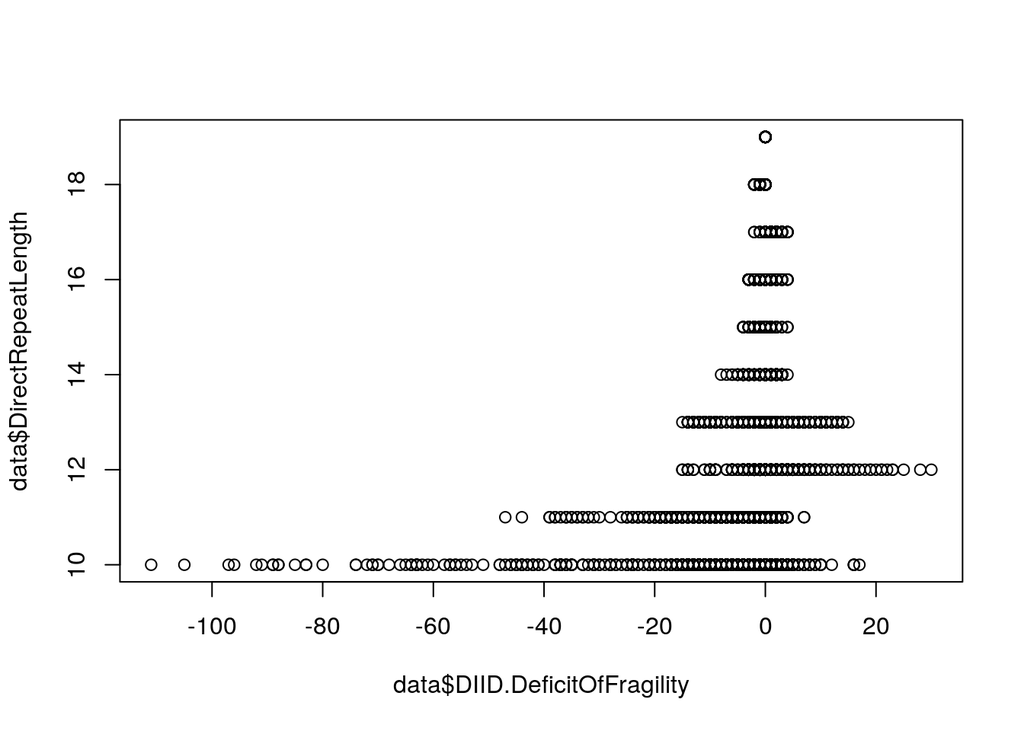

```r
plot(data$DIID.DeficitOfFragility,data$DirectRepeatLength)
```

```r
cor.test(data$DIID.DeficitOfFragility,data$InvertedRepeatLength, method = 'spearman')
```

```
##
##  Spearman's rank correlation rho
##
## data:  data$DIID.DeficitOfFragility and data$InvertedRepeatLength
## S = 9.7948e+10, p-value < 2.2e-16
## alternative hypothesis: true rho is not equal to 0
## sample estimates:
##       rho
## 0.1938415
```

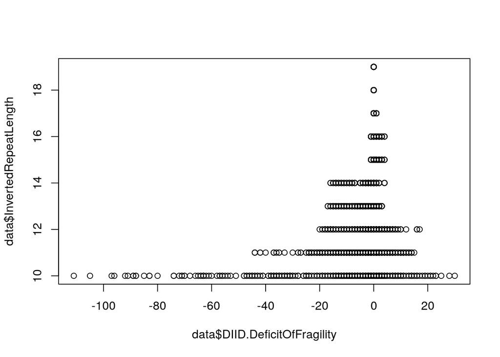

```r
plot(data$DIID.DeficitOfFragility,data$InvertedRepeatLength)
```

```r
cor.test(data$DIID.DeficitOfFragility,data$LengthOfInterval1, method = 'spearman')
```

```
##
##  Spearman's rank correlation rho
##
## data:  data$DIID.DeficitOfFragility and data$LengthOfInterval1
## S = 1.1706e+11, p-value = 0.0005184
## alternative hypothesis: true rho is not equal to 0
## sample estimates:
##        rho
## 0.03658124
```

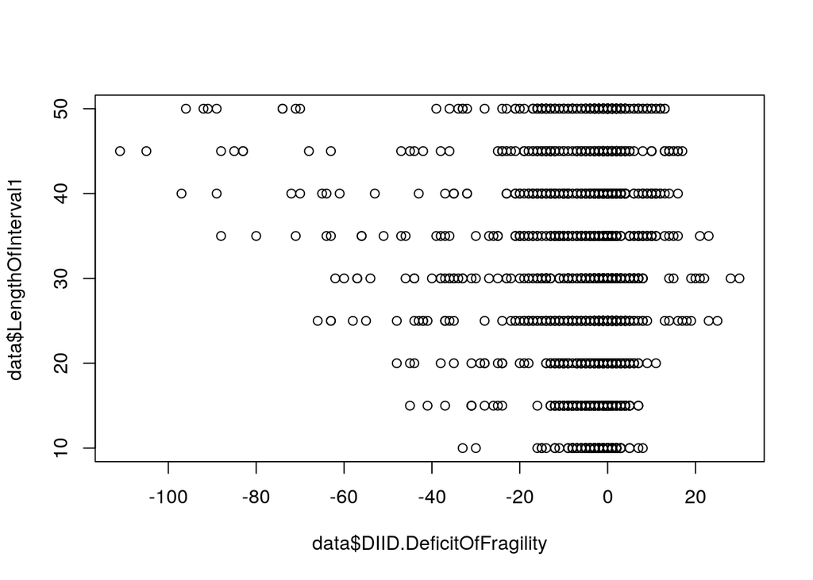

```r
plot(data$DIID.DeficitOfFragility,data$LengthOfInterval1)
```

```r
cor.test(data$DIID.DeficitOfFragility,data$LengthOfInterval2, method = 'spearman')
```

```
##
##  Spearman's rank correlation rho
##
## data:  data$DIID.DeficitOfFragility and data$LengthOfInterval2
## S = 1.2136e+11, p-value = 0.9142
## alternative hypothesis: true rho is not equal to 0
## sample estimates:
##         rho
## 0.001135997
```

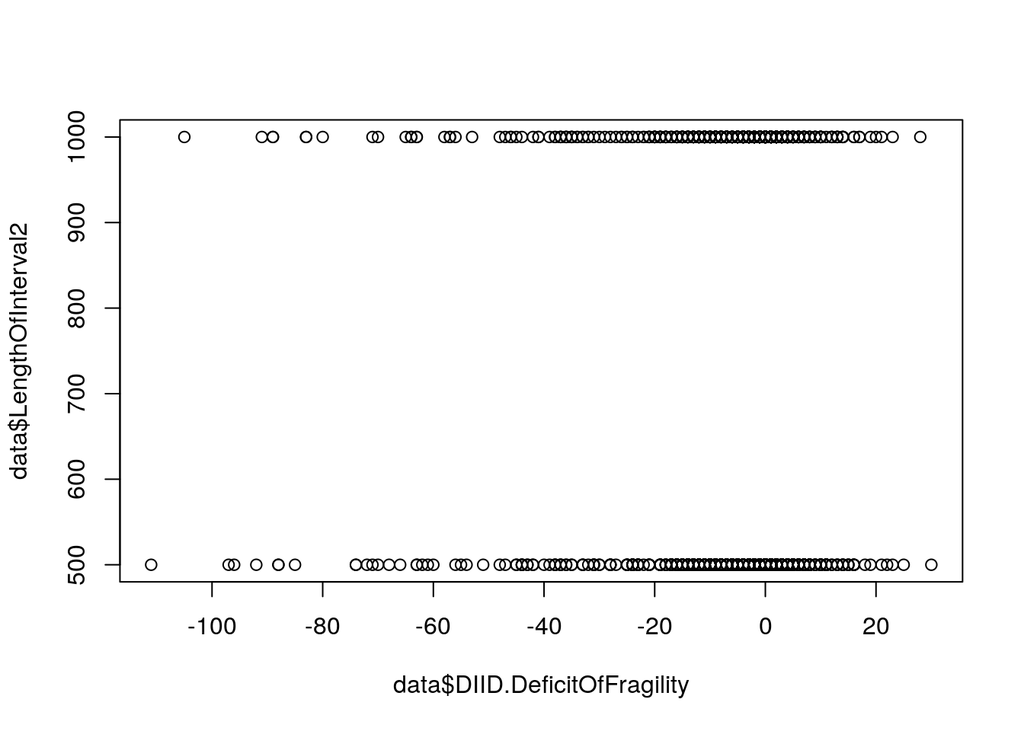

```r
plot(data$DIID.DeficitOfFragility,data$LengthOfInterval2)
```

```r
cor.test(data$DIID.DeficitOfFragility,data$LengthOfInterval3, method = 'spearman')
```

```
##
##  Spearman's rank correlation rho
##
## data:  data$DIID.DeficitOfFragility and data$LengthOfInterval3
## S = 1.2212e+11, p-value = 0.6297
## alternative hypothesis: true rho is not equal to 0
## sample estimates:
##          rho
## -0.005082915
```

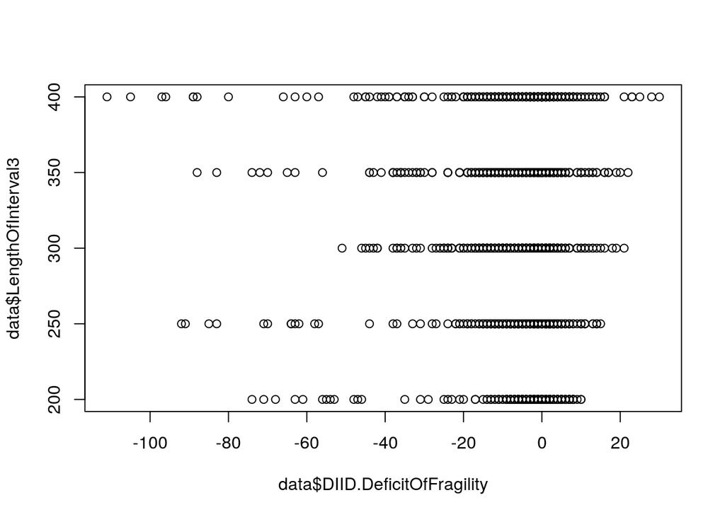

```r
plot(data$DIID.DeficitOfFragility,data$LengthOfInterval3)
```

```r
### MULTIVARIATE

summary(lm(data$DIID.DeficitOfFragility ~ scale(data$DirectRepeatLength) + scale(data$InvertedRepeatLength) + scale(data$LengthOfInterval1) + scale(data$LengthOfInterval2) + scale(data$LengthOfInterval3)))
```

```
##
## Call:
## lm(formula = data$DIID.DeficitOfFragility ~ scale(data$DirectRepeatLength) +
##     scale(data$InvertedRepeatLength) + scale(data$LengthOfInterval1) +
##     scale(data$LengthOfInterval2) + scale(data$LengthOfInterval3))
##
## Residuals:
##      Min       1Q   Median       3Q      Max
## -103.776   -1.148    0.541    2.017   35.658
##
## Coefficients:
##                                  Estimate Std. Error t value Pr(>|t|)
## (Intercept)                      -1.26033    0.06904 -18.255  < 2e-16 ***
## scale(data$DirectRepeatLength)    1.80809    0.06904  26.188  < 2e-16 ***
## scale(data$InvertedRepeatLength)  1.56909    0.06904  22.726  < 2e-16 ***
## scale(data$LengthOfInterval1)    -0.26441    0.06904  -3.830 0.000129 ***
## scale(data$LengthOfInterval2)     0.04322    0.06904   0.626 0.531294
## scale(data$LengthOfInterval3)    -0.22817    0.06904  -3.305 0.000954 ***
## ---
## Signif. codes:  0 '***' 0.001 '**' 0.01 '*' 0.05 '.' 0.1 ' ' 1
##
## Residual standard error: 6.55 on 8994 degrees of freedom
## Multiple R-squared:  0.1202, Adjusted R-squared:  0.1197
## F-statistic: 245.7 on 5 and 8994 DF,  p-value: < 2.2e-16
```

```r
summary(lm(data$DIID.DeficitOfFragility ~ scale(data$DirectRepeatLength) + scale(data$InvertedRepeatLength) + scale(data$LengthOfInterval1) + scale(data$LengthOfInterval3)))
```

```
##
## Call:
## lm(formula = data$DIID.DeficitOfFragility ~ scale(data$DirectRepeatLength) +
##     scale(data$InvertedRepeatLength) + scale(data$LengthOfInterval1) +
##     scale(data$LengthOfInterval3))
##
## Residuals:
##      Min       1Q   Median       3Q      Max
## -103.819   -1.149    0.537    2.013   35.615
##
## Coefficients:
##                                  Estimate Std. Error t value Pr(>|t|)
## (Intercept)                      -1.26033    0.06904 -18.256  < 2e-16 ***
## scale(data$DirectRepeatLength)    1.80809    0.06904  26.189  < 2e-16 ***
## scale(data$InvertedRepeatLength)  1.56909    0.06904  22.727  < 2e-16 ***
## scale(data$LengthOfInterval1)    -0.26441    0.06904  -3.830 0.000129 ***
## scale(data$LengthOfInterval3)    -0.22817    0.06904  -3.305 0.000954 ***
## ---
## Signif. codes:  0 '***' 0.001 '**' 0.01 '*' 0.05 '.' 0.1 ' ' 1
##
## Residual standard error: 6.549 on 8995 degrees of freedom
## Multiple R-squared:  0.1201, Adjusted R-squared:  0.1197
## F-statistic:   307 on 4 and 8995 DF,  p-value: < 2.2e-16
```

## 4: DG4IIDFragilityScore (==number of fragile with GQ / number of alternative structures)

### we expect that FragilityScore should decrease (due to selection) in case of:

### (i) long repeats (so we expect negative correlations between FragilityScore and length);

### (ii) short intervals 1 and 3 (so we expect positive correlations between FragilityScore and interval length)

```r
summary(data$DirectRepeatLength)
```

```
##    Min. 1st Qu.  Median    Mean 3rd Qu.    Max.
##    10.0    12.0    14.5    14.5    17.0    19.0
```

```r
summary(data$InvertedRepeatLength)
```

```
##    Min. 1st Qu.  Median    Mean 3rd Qu.    Max.
##    10.0    12.0    14.5    14.5    17.0    19.0
```

```r
summary(data$DG4IIDFragilityScore)
```

```
##     Min.  1st Qu.   Median     Mean  3rd Qu.     Max.
## 0.000000 0.000000 0.000000 0.006281 0.000000 2.000000
```

```r
### UNIVARIATE WITH DIIDFragilityScore

cor.test(data$DG4IIDFragilityScore,data$DirectRepeatLength, method = 'spearman')
```

```
##
##  Spearman's rank correlation rho
##
## data:  data$DG4IIDFragilityScore and data$DirectRepeatLength
## S = 1.3771e+11, p-value < 2.2e-16
## alternative hypothesis: true rho is not equal to 0
## sample estimates:
##        rho
## -0.1334323
```

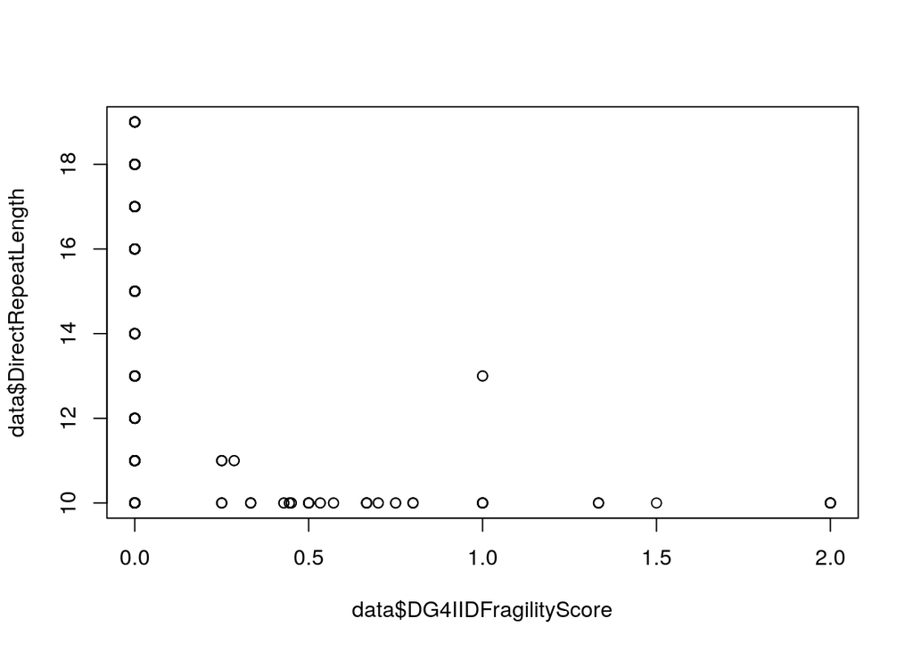

```r
plot(data$DG4IIDFragilityScore,data$DirectRepeatLength)
```

```r
cor.test(data$DG4IIDFragilityScore,data$InvertedRepeatLength, method = 'spearman')
```

```
##
##  Spearman's rank correlation rho
##
## data:  data$DG4IIDFragilityScore and data$InvertedRepeatLength
## S = 1.3643e+11, p-value < 2.2e-16
## alternative hypothesis: true rho is not equal to 0
## sample estimates:
##        rho
## -0.1228496
```

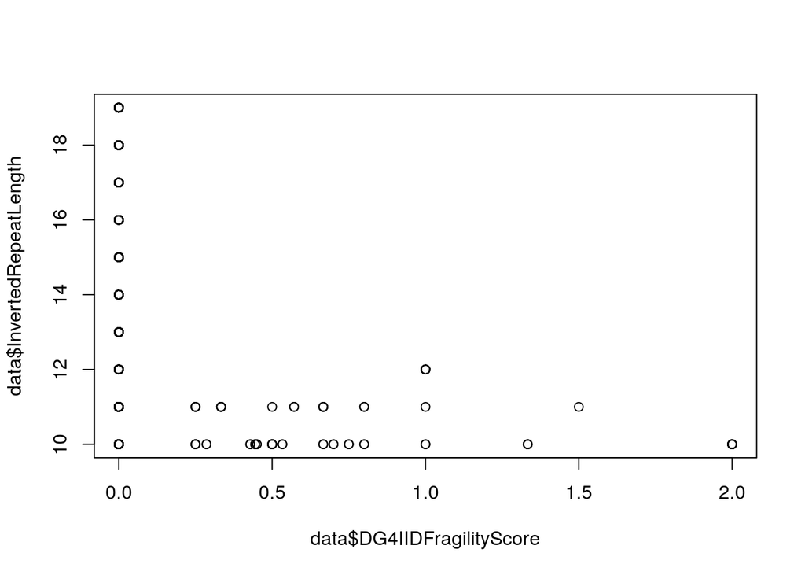

```r
plot(data$DG4IIDFragilityScore,data$InvertedRepeatLength)
```

```r
cor.test(data$DG4IIDFragilityScore,data$LengthOfInterval1, method = 'spearman')
```

```
##
##  Spearman's rank correlation rho
##
## data:  data$DG4IIDFragilityScore and data$LengthOfInterval1
## S = 1.0794e+11, p-value < 2.2e-16
## alternative hypothesis: true rho is not equal to 0
## sample estimates:
##       rho
## 0.1116346
```

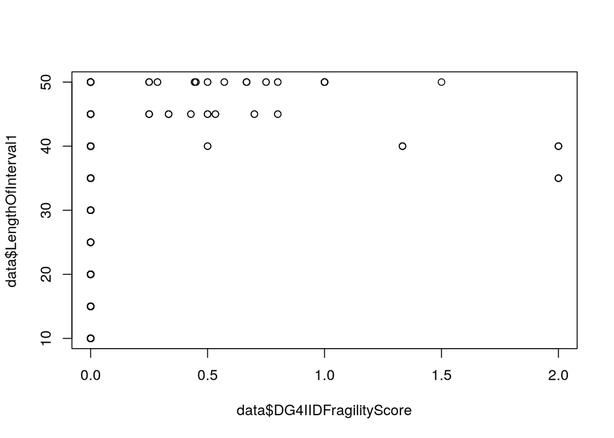

```r
plot(data$DG4IIDFragilityScore,data$LengthOfInterval1)
```

```r
cor.test(data$DG4IIDFragilityScore,data$LengthOfInterval2, method = 'spearman')
```

```
##
##  Spearman's rank correlation rho
##
## data:  data$DG4IIDFragilityScore and data$LengthOfInterval2
## S = 1.2181e+11, p-value = 0.8114
## alternative hypothesis: true rho is not equal to 0
## sample estimates:
##          rho
## -0.002515822
```

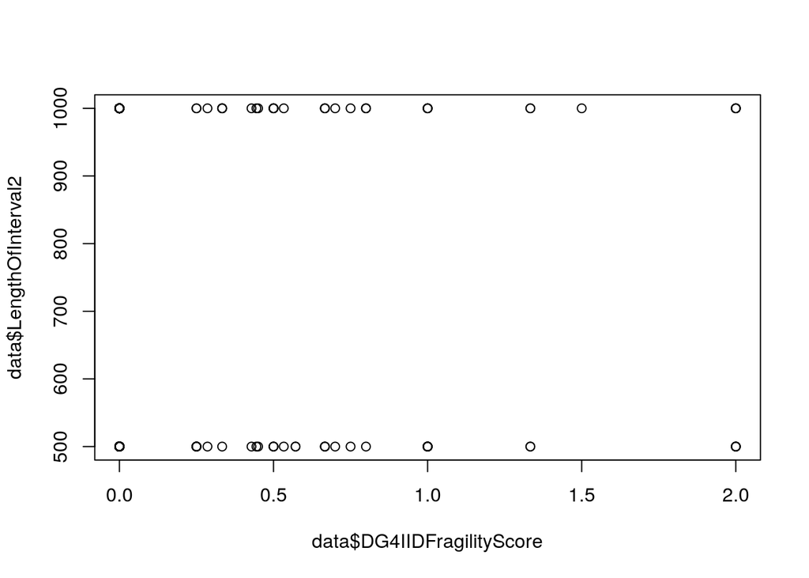

```r
plot(data$DG4IIDFragilityScore,data$LengthOfInterval2)
```

```r
cor.test(data$DG4IIDFragilityScore,data$LengthOfInterval3, method = 'spearman')
```

```
##
##  Spearman's rank correlation rho
##
## data:  data$DG4IIDFragilityScore and data$LengthOfInterval3
## S = 1.1943e+11, p-value = 0.1065
## alternative hypothesis: true rho is not equal to 0
## sample estimates:
##        rho
## 0.01701494
```

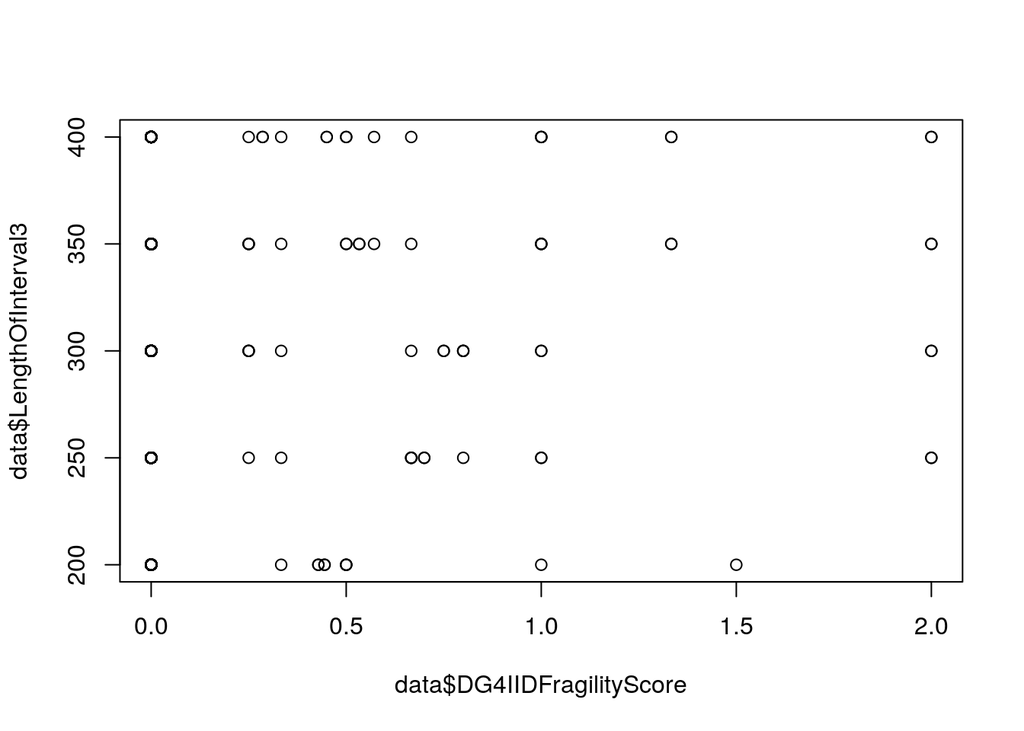

```r
plot(data$DG4IIDFragilityScore,data$LengthOfInterval3)
```

```r
### MULTIVARIATE

summary(lm(data$DG4IIDFragilityScore ~ scale(data$DirectRepeatLength) + scale(data$InvertedRepeatLength) + scale(data$LengthOfInterval1) + scale(data$LengthOfInterval2) + scale(data$LengthOfInterval3)))
```

```
##
## Call:
## lm(formula = data$DG4IIDFragilityScore ~ scale(data$DirectRepeatLength) +
##     scale(data$InvertedRepeatLength) + scale(data$LengthOfInterval1) +
##     scale(data$LengthOfInterval2) + scale(data$LengthOfInterval3))
##
## Residuals:
##      Min       1Q   Median       3Q      Max
## -0.04208 -0.01640 -0.00599  0.00460  1.96125
##
## Coefficients:
##                                    Estimate Std. Error t value Pr(>|t|)
## (Intercept)                       6.281e-03  8.802e-04   7.136 1.04e-12 ***
## scale(data$DirectRepeatLength)   -9.548e-03  8.802e-04 -10.847  < 2e-16 ***
## scale(data$InvertedRepeatLength) -8.793e-03  8.802e-04  -9.990  < 2e-16 ***
## scale(data$LengthOfInterval1)     7.073e-03  8.802e-04   8.035 1.05e-15 ***
## scale(data$LengthOfInterval2)    -6.032e-05  8.802e-04  -0.069   0.9454
## scale(data$LengthOfInterval3)     1.495e-03  8.802e-04   1.699   0.0894 .
## ---
## Signif. codes:  0 '***' 0.001 '**' 0.01 '*' 0.05 '.' 0.1 ' ' 1
##
## Residual standard error: 0.0835 on 8994 degrees of freedom
## Multiple R-squared:  0.0307, Adjusted R-squared:  0.03017
## F-statistic: 56.98 on 5 and 8994 DF,  p-value: < 2.2e-16
```

```r
summary(lm(data$DG4IIDFragilityScore ~ scale(data$DirectRepeatLength) + scale(data$InvertedRepeatLength) + scale(data$LengthOfInterval1) + scale(data$LengthOfInterval3)))
```

```
##
## Call:
## lm(formula = data$DG4IIDFragilityScore ~ scale(data$DirectRepeatLength) +
##     scale(data$InvertedRepeatLength) + scale(data$LengthOfInterval1) +
##     scale(data$LengthOfInterval3))
##
## Residuals:
##      Min       1Q   Median       3Q      Max
## -0.04202 -0.01639 -0.00599  0.00460  1.96119
##
## Coefficients:
##                                    Estimate Std. Error t value Pr(>|t|)
## (Intercept)                       0.0062808  0.0008801   7.136 1.03e-12 ***
## scale(data$DirectRepeatLength)   -0.0095477  0.0008802 -10.848  < 2e-16 ***
## scale(data$InvertedRepeatLength) -0.0087932  0.0008802  -9.990  < 2e-16 ***
## scale(data$LengthOfInterval1)     0.0070729  0.0008802   8.036 1.05e-15 ***
## scale(data$LengthOfInterval3)     0.0014954  0.0008802   1.699   0.0894 .
## ---
## Signif. codes:  0 '***' 0.001 '**' 0.01 '*' 0.05 '.' 0.1 ' ' 1
##
## Residual standard error: 0.0835 on 8995 degrees of freedom
## Multiple R-squared:  0.0307, Adjusted R-squared:  0.03027
## F-statistic: 71.23 on 4 and 8995 DF,  p-value: < 2.2e-16
```